# Project: TMDb movie data

- Introduction
- Data Wrangling
- Exploratory Data Analysis
- Conclusions

## Introduction

### Dataset Description

> In this project, we will investigatea dataset named "TMDb movie data", which is about the movies released from 1960 until 2015, its review average , popularity and many other features. this dataset has 21 attributes, namely id, imdb_id, popularity, budget, revenue, original title, cast,homepage, director, website,overview, runtime,genres, production_companies, release_date, vote_count, vote_average, release_year, budget_adj, revenue_adj. The significant columns in this investigation would be popularity, revenues, budget,release year,runtime, vote count, vote average.

## Extract Data

```python
#importing the necessary  libraries
import numpy as np
import pandas as pd
import matplotlib.pyplot as plt
import seaborn as  sn
%matplotlib inline
```

```python
# Loading data
df=pd.read_csv('tmdb-movies.csv')
df.head()
```

|  | id | imdb_id | popularity | budget | revenue | original_title | cast | homepage | director | tagline | ... | overview | runtime | genres | production_companies | release_date | vote_count | vote_average | release_year | budget_adj | revenue_adj |
| --- | --- | --- | --- | --- | --- | --- | --- | --- | --- | --- | --- | --- | --- | --- | --- | --- | --- | --- | --- | --- | --- |
| 0 | 135397 | tt0369610 | 32.985763 | 150000000 | 1513528810 | Jurassic World | Chris Pratt\|Bryce Dallas Howard\|Irrfan Khan\|Vi... | http://www.jurassicworld.com/ | Colin Trevorrow | The park is open. | ... | Twenty-two years after the events of Jurassic ... | 124 | Action\|Adventure\|Science Fiction\|Thriller | Universal Studios\|Amblin Entertainment\|Legenda... | 6/9/15 | 5562 | 6.5 | 2015 | 1.379999e+08 | 1.392446e+09 |
| 1 | 76341 | tt1392190 | 28.419936 | 150000000 | 378436354 | Mad Max: Fury Road | Tom Hardy\|Charlize Theron\|Hugh Keays-Byrne\|Nic... | http://www.madmaxmovie.com/ | George Miller | What a Lovely Day. | ... | An apocalyptic story set in the furthest reach... | 120 | Action\|Adventure\|Science Fiction\|Thriller | Village Roadshow Pictures\|Kennedy Miller Produ... | 5/13/15 | 6185 | 7.1 | 2015 | 1.379999e+08 | 3.481613e+08 |
| 2 | 262500 | tt2908446 | 13.112507 | 110000000 | 295238201 | Insurgent | Shailene Woodley\|Theo James\|Kate Winslet\|Ansel... | http://www.thedivergentseries.movie/#insurgent | Robert Schwentke | One Choice Can Destroy You | ... | Beatrice Prior must confront her inner demons ... | 119 | Adventure\|Science Fiction\|Thriller | Summit Entertainment\|Mandeville Films\|Red Wago... | 3/18/15 | 2480 | 6.3 | 2015 | 1.012000e+08 | 2.716190e+08 |
| 3 | 140607 | tt2488496 | 11.173104 | 200000000 | 2068178225 | Star Wars: The Force Awakens | Harrison Ford\|Mark Hamill\|Carrie Fisher\|Adam D... | http://www.starwars.com/films/star-wars-episod... | J.J. Abrams | Every generation has a story. | ... | Thirty years after defeating the Galactic Empi... | 136 | Action\|Adventure\|Science Fiction\|Fantasy | Lucasfilm\|Truenorth Productions\|Bad Robot | 12/15/15 | 5292 | 7.5 | 2015 | 1.839999e+08 | 1.902723e+09 |
| 4 | 168259 | tt2820852 | 9.335014 | 190000000 | 1506249360 | Furious 7 | Vin Diesel\|Paul Walker\|Jason Statham\|Michelle ... | http://www.furious7.com/ | James Wan | Vengeance Hits Home | ... | Deckard Shaw seeks revenge against Dominic Tor... | 137 | Action\|Crime\|Thriller | Universal Pictures\|Original Film\|Media Rights ... | 4/1/15 | 2947 | 7.3 | 2015 | 1.747999e+08 | 1.385749e+09 |

5 rows × 21 columns

## Data Wrangling

In this section of the report, we will load in the data, check for cleanliness, and then trim and clean dataset for analysis.

```python
#finding  the shape of the data frame (total num of  columns and  rows), we have 10866 rows and  21  columns
df.shape
```

```
(10866, 21)
```

```python
#getting information about the data types,  no of enteries and the  number of  nulls
df.info()
```

```
<class 'pandas.core.frame.DataFrame'>
RangeIndex: 10866 entries, 0 to 10865
Data columns (total 21 columns):
 #   Column                Non-Null Count  Dtype
---  ------                --------------  -----
 0   id                    10866 non-null  int64
 1   imdb_id               10856 non-null  object
 2   popularity            10866 non-null  float64
 3   budget                10866 non-null  int64
 4   revenue               10866 non-null  int64
 5   original_title        10866 non-null  object
 6   cast                  10790 non-null  object
 7   homepage              2936 non-null   object
 8   director              10822 non-null  object
 9   tagline               8042 non-null   object
 10  keywords              9373 non-null   object
 11  overview              10862 non-null  object
 12  runtime               10866 non-null  int64
 13  genres                10843 non-null  object
 14  production_companies  9836 non-null   object
 15  release_date          10866 non-null  object
 16  vote_count            10866 non-null  int64
 17  vote_average          10866 non-null  float64
 18  release_year          10866 non-null  int64
 19  budget_adj            10866 non-null  float64
 20  revenue_adj           10866 non-null  float64
dtypes: float64(4), int64(6), object(11)
memory usage: 1.7+ MB
```

```python
#finding Unique values of each column
df.nunique()
```

```
id                      10865
imdb_id                 10855
popularity              10814
budget                    557
revenue                  4702
original_title          10571
cast                    10719
homepage                 2896
director                 5067
tagline                  7997
keywords                 8804
overview                10847
runtime                   247
genres                   2039
production_companies     7445
release_date             5909
vote_count               1289
vote_average               72
release_year               56
budget_adj               2614
revenue_adj              4840
dtype: int64
```

```python
#checking for duplicates
df.duplicated().sum()
```

```
1
```

```python
#checking  some statistics about the dataset
df.describe()
```

|  | id | popularity | budget | revenue | runtime | vote_count | vote_average | release_year | budget_adj | revenue_adj |
| --- | --- | --- | --- | --- | --- | --- | --- | --- | --- | --- |
| count | 10866.000000 | 10866.000000 | 1.086600e+04 | 1.086600e+04 | 10866.000000 | 10866.000000 | 10866.000000 | 10866.000000 | 1.086600e+04 | 1.086600e+04 |
| mean | 66064.177434 | 0.646441 | 1.462570e+07 | 3.982332e+07 | 102.070863 | 217.389748 | 5.974922 | 2001.322658 | 1.755104e+07 | 5.136436e+07 |
| std | 92130.136561 | 1.000185 | 3.091321e+07 | 1.170035e+08 | 31.381405 | 575.619058 | 0.935142 | 12.812941 | 3.430616e+07 | 1.446325e+08 |
| min | 5.000000 | 0.000065 | 0.000000e+00 | 0.000000e+00 | 0.000000 | 10.000000 | 1.500000 | 1960.000000 | 0.000000e+00 | 0.000000e+00 |
| 25% | 10596.250000 | 0.207583 | 0.000000e+00 | 0.000000e+00 | 90.000000 | 17.000000 | 5.400000 | 1995.000000 | 0.000000e+00 | 0.000000e+00 |
| 50% | 20669.000000 | 0.383856 | 0.000000e+00 | 0.000000e+00 | 99.000000 | 38.000000 | 6.000000 | 2006.000000 | 0.000000e+00 | 0.000000e+00 |
| 75% | 75610.000000 | 0.713817 | 1.500000e+07 | 2.400000e+07 | 111.000000 | 145.750000 | 6.600000 | 2011.000000 | 2.085325e+07 | 3.369710e+07 |
| max | 417859.000000 | 32.985763 | 4.250000e+08 | 2.781506e+09 | 900.000000 | 9767.000000 | 9.200000 | 2015.000000 | 4.250000e+08 | 2.827124e+09 |

## Data cleansing

```python
# dropping all  duplicates
df.drop_duplicates(inplace=True)
```

```python
#checking  for duplicates again
df.duplicated().sum()
```

```
0
```

```python
# dropping unnecessary columns  for out investigation
df.drop(['imdb_id','homepage','keywords','overview'],inplace=True,axis=1)
```

```python
#droping  all null values
df.dropna(inplace=True)
df.info()
```

```
<class 'pandas.core.frame.DataFrame'>
Int64Index: 7635 entries, 0 to 10865
Data columns (total 17 columns):
 #   Column                Non-Null Count  Dtype
---  ------                --------------  -----
 0   id                    7635 non-null   int64
 1   popularity            7635 non-null   float64
 2   budget                7635 non-null   int64
 3   revenue               7635 non-null   int64
 4   original_title        7635 non-null   object
 5   cast                  7635 non-null   object
 6   director              7635 non-null   object
 7   tagline               7635 non-null   object
 8   runtime               7635 non-null   int64
 9   genres                7635 non-null   object
 10  production_companies  7635 non-null   object
 11  release_date          7635 non-null   object
 12  vote_count            7635 non-null   int64
 13  vote_average          7635 non-null   float64
 14  release_year          7635 non-null   int64
 15  budget_adj            7635 non-null   float64
 16  revenue_adj           7635 non-null   float64
dtypes: float64(4), int64(6), object(7)
memory usage: 1.0+ MB
```

```python
#checking if there are still nulls
df.isnull().sum().sum()
```

```
0
```

## Exploratory Data Analysis

### (what factors are affecting the total revenues?)

```python
#finding the correlation between different  attributes
df.corr(method ='pearson')
```

|  | id | popularity | budget | revenue | runtime | vote_count | vote_average | release_year | budget_adj | revenue_adj |
| --- | --- | --- | --- | --- | --- | --- | --- | --- | --- | --- |
| id | 1.000000 | 0.033333 | -0.121707 | -0.083786 | -0.087441 | -0.007856 | -0.121733 | 0.498926 | -0.178731 | -0.132377 |
| popularity | 0.033333 | 1.000000 | 0.526750 | 0.655974 | 0.180568 | 0.800421 | 0.273718 | 0.148734 | 0.492086 | 0.598800 |
| budget | -0.121707 | 0.526750 | 1.000000 | 0.728081 | 0.235405 | 0.620307 | 0.113108 | 0.190130 | 0.967932 | 0.608024 |
| revenue | -0.083786 | 0.655974 | 0.728081 | 1.000000 | 0.208476 | 0.784083 | 0.220005 | 0.107901 | 0.699914 | 0.916314 |
| runtime | -0.087441 | 0.180568 | 0.235405 | 0.208476 | 1.000000 | 0.213868 | 0.253775 | -0.107365 | 0.275822 | 0.225992 |
| vote_count | -0.007856 | 0.800421 | 0.620307 | 0.784083 | 0.213868 | 1.000000 | 0.317844 | 0.161194 | 0.573070 | 0.698244 |
| vote_average | -0.121733 | 0.273718 | 0.113108 | 0.220005 | 0.253775 | 0.317844 | 1.000000 | -0.149144 | 0.128912 | 0.246261 |
| release_year | 0.498926 | 0.148734 | 0.190130 | 0.107901 | -0.107365 | 0.161194 | -0.149144 | 1.000000 | 0.085203 | -0.029786 |
| budget_adj | -0.178731 | 0.492086 | 0.967932 | 0.699914 | 0.275822 | 0.573070 | 0.128912 | 0.085203 | 1.000000 | 0.634936 |
| revenue_adj | -0.132377 | 0.598800 | 0.608024 | 0.916314 | 0.225992 | 0.698244 | 0.246261 | -0.029786 | 0.634936 | 1.000000 |

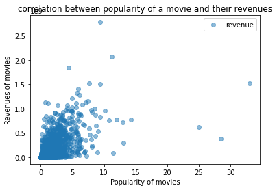

```python
#plotting the correlation between the popularity and  revenues, they tend to have a positive correlation
plt.figure(figsize=(12,12))
df.plot(x='popularity',y='revenue', style='o',alpha=0.5);
plt.legend()
plt.title('correlation between popularity of a movie and their revenues')
plt.xlabel('Popularity of movies')
plt.ylabel('Revenues of movies')
plt.show();
```

it is obvious that there is a positive moderate correlation between the popularity of th movies and their revenures. So that is the movie is more popular, it tends to have more revenues.

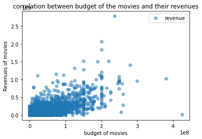

```python
##plotting the correlation between the budget and  revenues, they tend to have a positive correlation
plt.figure(figsize=(12,12))
df.plot(x='budget',y='revenue', style='o',alpha=0.5)
plt.legend()
plt.title('correlation between budget of the movies and their revenues')
plt.xlabel('budget of movies')
plt.ylabel('Revenues of movies')
plt.show();
```

there is a strong positive correlation between the revenues of the movies and their budget. In other words, the more the budget set for the movie making, the more revenues it tends to get

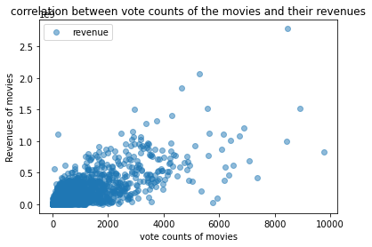

```python
##plotting the correlation between the budget and  revenues, they tend to have a positive correlation
plt.figure(figsize=(12,12))
df.plot(x='vote_count',y='revenue', style='o',alpha=0.5)
plt.legend()
plt.title('correlation between vote counts of the movies and their revenues')
plt.xlabel('vote counts of movies')
plt.ylabel('Revenues of movies')
plt.show();
```

there is a strong positive correlation between the revenues of the movies and their vote count. In other words, the more votes the movie gets, the more revenues it tends to earn.

```python
# making anew dataframe of only  revenues and budget
data = [df["revenue"], df["budget"]]

df1 = pd.concat(data, axis=1)
```

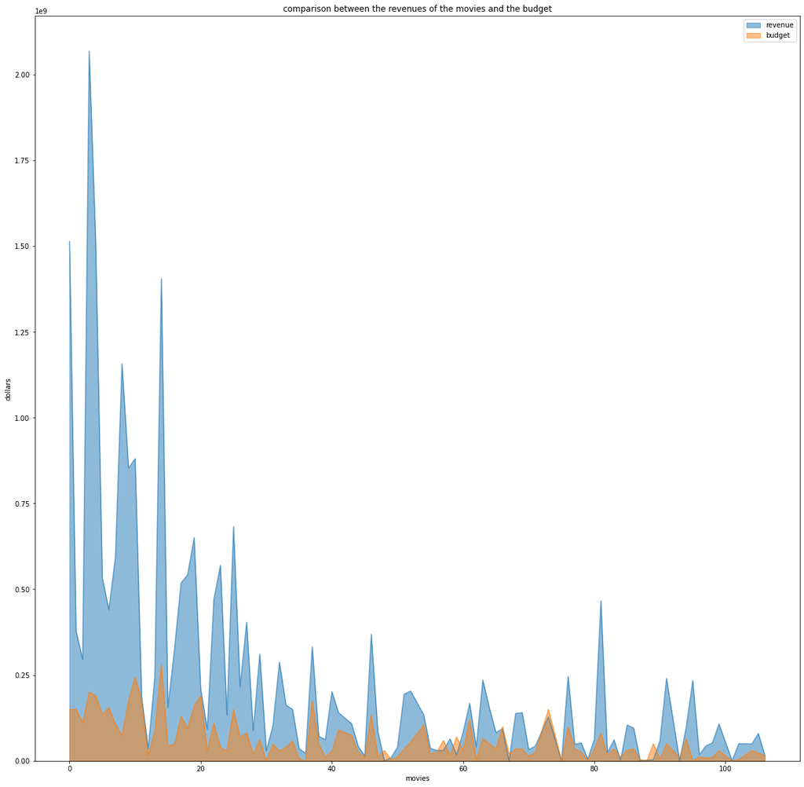

```python
#checking the relation between the  budget and revenues
ax = df1.head(100).plot.area(stacked=False,figsize=(20,20))
plt.xlabel('movies')
plt.ylabel('dollars')
plt.title('comparison between the revenues of the movies and the budget')
plt.show()
```

in the area plot above, it shows the relevance between the budget and the revenues of a movie.

### which gerne has more movies?

```python
#  we separate the  gernes based on "|" and then we  count the   number of each gerne
counts_of_gernes = pd.Series(df['genres'].str.cat(sep = '|').split('|')).value_counts()
counts_of_gernes
```

```
Drama              3352
Comedy             2724
Thriller           2329
Action             1887
Horror             1285
Romance            1216
Adventure          1154
Crime              1131
Science Fiction     972
Family              824
Fantasy             683
Mystery             648
Animation           399
Music               248
History             216
War                 201
Documentary         175
Western             136
TV Movie             65
Foreign              54
dtype: int64
```

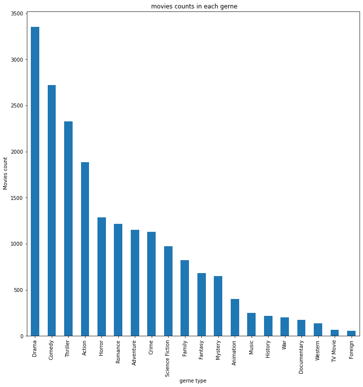

```python
#plotting the movies  counts in  each gerne
counts_of_gernes.plot.bar(figsize=(12,12))

plt.title(' movies counts in each gerne')
plt.xlabel('gerne type')
plt.ylabel(' Movies count')
plt.show()
```

from 1960 to 2015, the most common gerne of movies is the Drama followed by Comedy, thriller, Action and Horror.

### which cast member makes more movies?

```python
cast_counts = pd.Series(df['cast'].str.cat(sep = '|').split('|')).value_counts()
cast_counts.head()
```

```
Robert De Niro       66
Samuel L. Jackson    60
Bruce Willis         58
Nicolas Cage         54
Robin Williams       50
dtype: int64
```

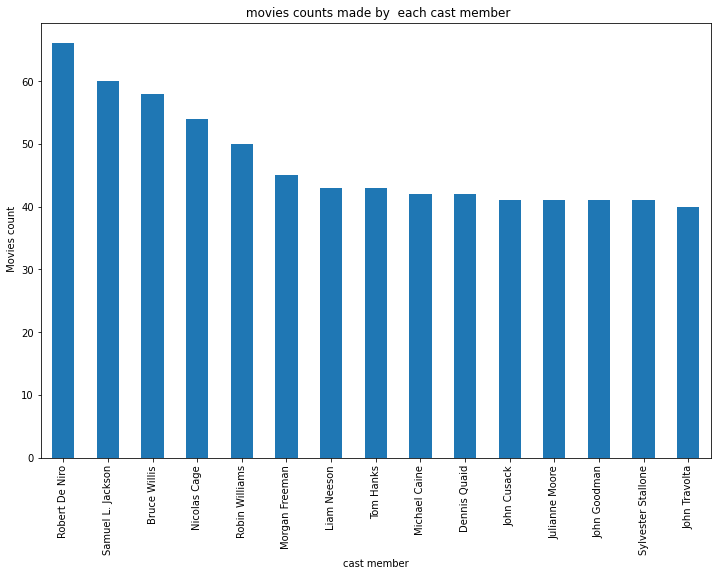

```python
#plotting the top cast members made movies
cast_counts.head(15).plot.bar(figsize=(12,8))

plt.title(' movies counts made by  each cast member')
plt.xlabel('cast member')
plt.ylabel(' Movies count')
plt.show()
```

The most cast member who made ovies is Robert De Niro followed by Samuel Jackson.

### which companies make more movies?

```python
top_comps=df['production_companies'].value_counts().head(20)
top_comps
```

```
Paramount Pictures                          141
Universal Pictures                          117
Warner Bros.                                 69
Columbia Pictures                            67
Metro-Goldwyn-Mayer (MGM)                    65
Walt Disney Pictures                         56
New Line Cinema                              54
Touchstone Pictures                          45
Twentieth Century Fox Film Corporation       43
20th Century Fox                             39
TriStar Pictures                             36
Orion Pictures                               34
Walt Disney Productions                      28
Columbia Pictures Corporation                26
Miramax Films                                26
Dimension Films                              21
United Artists                               20
Imagine Entertainment|Universal Pictures     20
DreamWorks Animation                         18
Marvel Studios                               17
Name: production_companies, dtype: int64
```

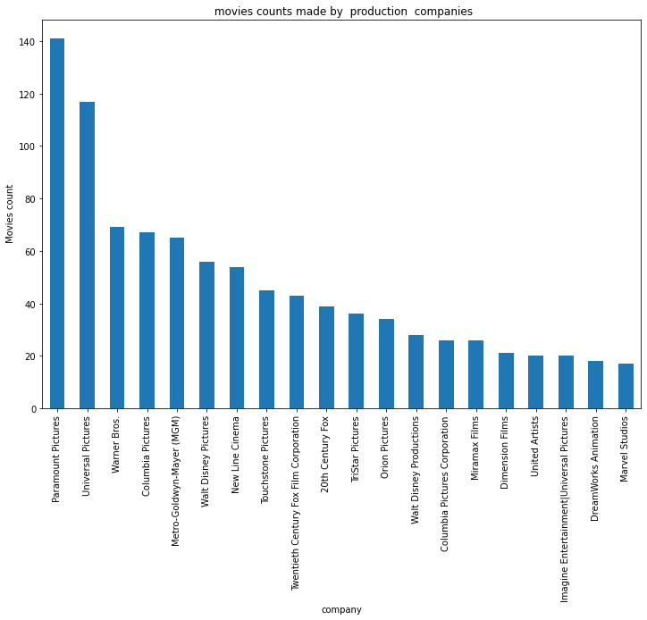

```python
#plotting the top cast members made movies
top_comps.plot.bar(figsize=(12,8))
plt.title(' movies counts made by  production  companies')
plt.xlabel('company')
plt.ylabel(' Movies count')
plt.show()
```

the top companie which made more movies is Paramount pics with 140 movies made.

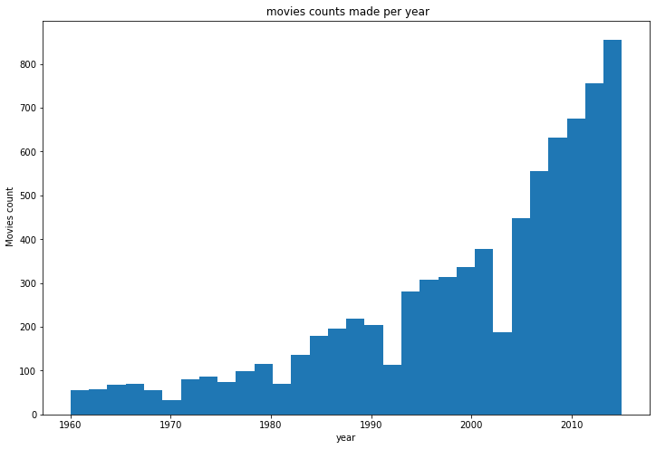

```python
#movies made every year
plt.figure(figsize=(12,8))
plt.hist(data = df, x = 'release_year',bins=30)
plt.title(' movies counts made per year')
plt.xlabel('year')
plt.ylabel(' Movies count');
```

In the chart above, it seems that the film industry is in progress and the movies released every year is in increase from 1960 to 2015

### (is there a big difference between the number of movies released before and after 2000? does the number of movies released increase every year?)

```python
#knowing the  first release year
df.release_year.min()
```

```
1960
```

```python
##knowing the  last release year
df.release_year.max()
```

```
2015
```

```python
#defining the  years before and after 2000
before_2000=df.release_year<2000
after_2000=df.release_year>=2000
```

```python
# number of movies released before 2000
df[before_2000].count()
```

```
id                      2981
popularity              2981
budget                  2981
revenue                 2981
original_title          2981
cast                    2981
director                2981
tagline                 2981
runtime                 2981
genres                  2981
production_companies    2981
release_date            2981
vote_count              2981
vote_average            2981
release_year            2981
budget_adj              2981
revenue_adj             2981
dtype: int64
```

```python
#number of movies released after 2000
df[after_2000].count()
```

```
id                      4654
popularity              4654
budget                  4654
revenue                 4654
original_title          4654
cast                    4654
director                4654
tagline                 4654
runtime                 4654
genres                  4654
production_companies    4654
release_date            4654
vote_count              4654
vote_average            4654
release_year            4654
budget_adj              4654
revenue_adj             4654
dtype: int64
```

the number of the movies made before 2000 (40 years) is much less than the movies made after 2000 (15 years)

## which director made movies with top revenues?

```python
# getting the  top  10 largest  values after grouping by  director and  summing all revenues his  movies made
df1=df.groupby('director')['revenue'].sum().nlargest(10)
df1
```

```
director
Steven Spielberg     8743270322
Peter Jackson        6523244659
James Cameron        5841894863
Michael Bay          4917208171
Christopher Nolan    4167548502
David Yates          4154295625
Chris Columbus       3851491668
Robert Zemeckis      3707918494
Tim Burton           3665414624
Ridley Scott         3639696480
Name: revenue, dtype: int64
```

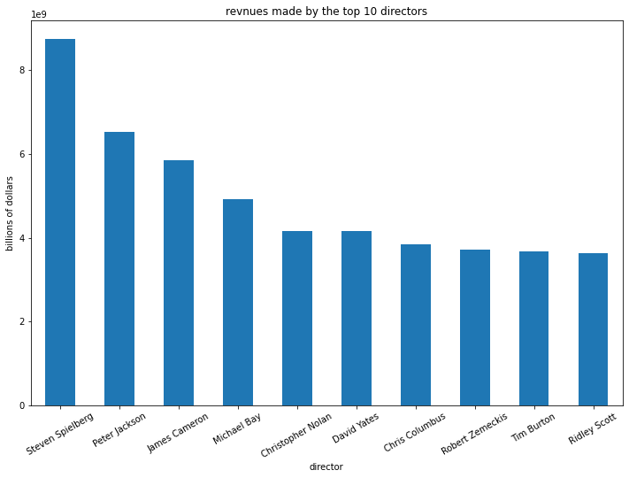

```python
#  top directors who made movies  with top revenues
plt.figure(figsize=(12,8))
df1.plot.bar()
plt.title('revnues made by the top 10 directors')
plt.xlabel( 'director')
plt.ylabel('billions of dollars')
plt.xticks(rotation=30);
```

it is obvious that the top director who made movies with top revenues is Steven Spielberg with almost 8.7 billions of dollars

## which movie genre makes more revenues?

```python
# getting the  top  10 largest  values after grouping by  genres and  summing all revenues  of the movies in that gerne

df2=df.groupby('genres')['revenue'].sum().nlargest(20)
df2
```

```
genres
Comedy                                      20036586641
Drama                                       14454439992
Comedy|Romance                              11237130588
Adventure|Fantasy|Action                     7597483556
Comedy|Drama|Romance                         6855355028
Animation|Family                             6530883026
Action|Adventure|Science Fiction             6420484308
Drama|Romance                                6107043319
Adventure|Fantasy|Family                     6079516484
Adventure|Action|Science Fiction             5256276988
Adventure|Action|Thriller                    5189472468
Action|Adventure|Fantasy|Science Fiction     4928441131
Action|Thriller                              4904614944
Comedy|Drama                                 4562243592
Animation|Comedy|Family                      4514573150
Science Fiction|Action|Adventure             4073416568
Horror|Thriller                              3906533380
Action|Crime|Thriller                        3850998817
Action|Adventure|Thriller                    3675044176
Adventure|Family|Fantasy                     3465858486
Name: revenue, dtype: int64
```

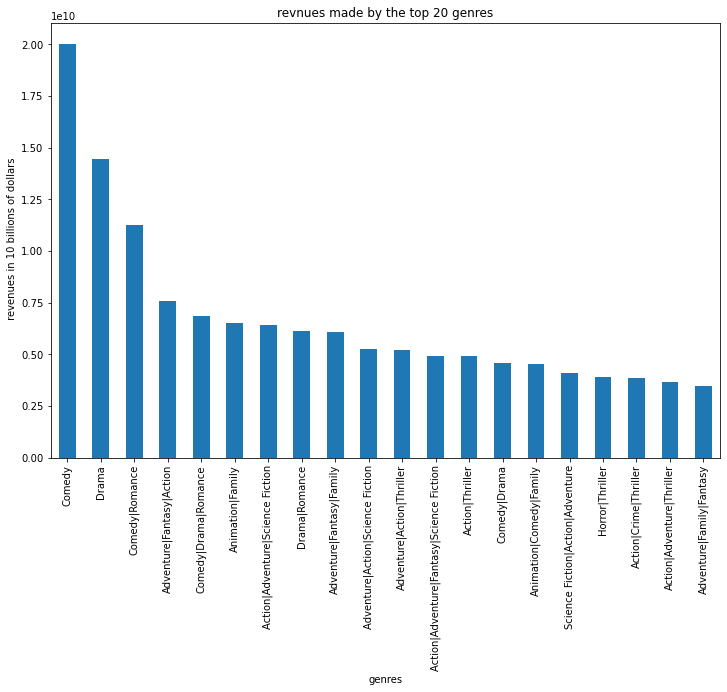

```python
#  top gernes  with  movies   made  top revenues
plt.figure(figsize=(12,8))
df2.plot.bar()
plt.title('revnues made by the top 20 genres')
plt.xlabel( 'genres')
plt.ylabel(' revenues in 10 billions of dollars');
```

the top gerne with movies that made more revenues is Comedy followed by Drama.

# conclusion

In this project, I have gathered the data from a csv file then I wrangled the data ro understand the data types and the number of rows and columns. Then I discovered the number of duplicates and NULL values in the data set. The following step was to cleanse the data by dropping the NULL values and Duplicates. Further, the exploration process and found some insights that answered some resaerch Questions:

- what factors are affecting the total revenues? I found a positive correlation between revnues and movie budget, popularity and vote count
- which gerne has more movies? from 1960 to 2015, the most common gerne of movies is the Drama followed by Comedy, thriller, Action and Horror.
- which cast member makes more movies? The most cast member who made ovies is Robert De Niro followed by Samuel Jackson.
- which companies make more movies? the top companie which made more movies is Paramount pics with 140 movies made.
- is there a big difference between the number of movies released before and after 2000? does the number of movies released increase every year? the number of the movies made before 2000 (40 years) is much less than the movies made after 2000 (15 years)
- which director made movies with top revenues? it is obvious that the top director who made movies with top revenues is Steven Spielberg with almost 8.7 billions of dollars
- which movie genre makes more revenues? the top gerne with movies that made more revenues is Comedy followed by Drama.